# Mixed models 2

Fitting, testing and troubleshooting

Dr Massimiliano Canzi

# Mixed models in practice

`Did you know:` octopus has three English plurals: *octopuses*, *octopi* (the oldest, from the idea that a Latin-looking word needs a Latin ending) and the rare *octopodes* (from the idea that it is Greek).

*Source: Merriam-Webster*

## Today

- Simulating a data set where we know the truth
- Fitting and reading an `lmer()` model
- Extracting estimates, random effects, confidence intervals and predictions
- Significance testing: likelihood ratio tests
- Common mistakes, made on purpose
- `R²`, convergence problems and singular fits

## Last week

- Repeated measures are not independent: data from the same speaker or word are alike
- Mixed models add varying intercepts and varying slopes for each grouping factor
- `(1 + x | speaker)` for predictors that vary within speakers; `(1 | word)` when x does not vary within words
- Without varying slopes, standard errors are too small

Today: doing it properly, from simulation to write-up.

# Simulating vowel durations

## Why simulate?

With real data, we never know the true effects. With simulated data, we do, so we can check whether the model recovers them.

Like Winter (2019, section 15.2), we simulate vowel durations. Our design:

- 16 speakers each read the same 24 words. Half the words end in a voiced consonant, half in a voiceless one
- True voicing effect: vowels 20 ms longer before voiced consonants

## The simulation

```r
set.seed(1)
n_speakers <- 16
n_words    <- 24

speakers <- tibble(speaker = sprintf("S%02d", 1:n_speakers),
                   s0 = rnorm(n_speakers, 0, 25),     # speaker's own speed
                   s1 = rnorm(n_speakers, 0, 12))     # speaker's own voicing effect
words <- tibble(word    = sprintf("w%02d", 1:n_words),
                voicing = rep(c("voiceless", "voiced"), each = n_words / 2),
                w0      = rnorm(n_words, 0, 15))     # word's own duration

vowels <- crossing(speakers, words) |>
  mutate(duration = round(150 + s0 + w0 +
                          (20 + s1) * (voicing == "voiced") +
                          rnorm(n(), 0, 20)),
         voicing = factor(voicing, levels = c("voiceless", "voiced"))) |>
  select(speaker, word, voicing, duration)
```

`(voicing == "voiced")` is `TRUE` or `FALSE`, which R treats as 1 or 0: a dummy variable, as in lecture 7.

## The data

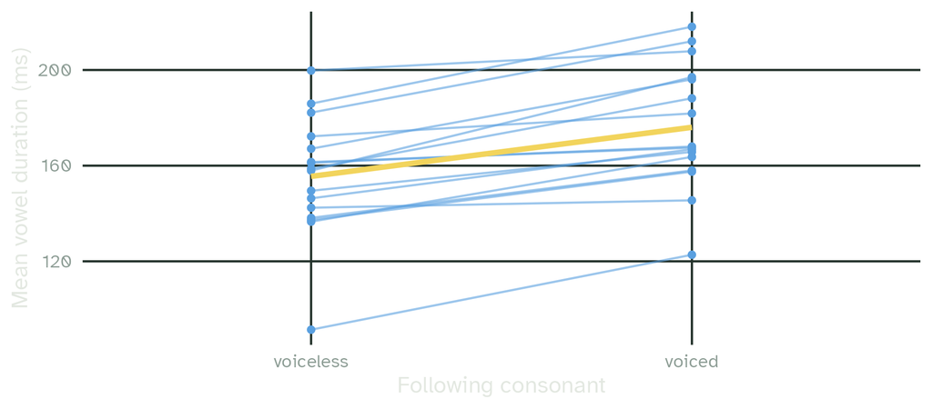

# Fitting the model

`Did you know:` octopuses have three hearts and blue blood: their blood carries oxygen with copper-based hemocyanin, not iron-based haemoglobin.

*Source: Smithsonian Magazine*

## Which random effects?

Every speaker produces both voiced and voiceless words, so voicing varies within speakers and can get a slope: `(1 + voicing | speaker)`. Each word is either voiced or voiceless, so words get only an intercept: `(1 | word)`.

```r
m <- lmer(duration ~ voicing + (1 + voicing | speaker) + (1 | word),
          data = vowels)
```

The maximal random effects structure justified by the design (Barr et al., 2013, lecture 10).

## `summary()`

```r
summary(m)
```

```
Linear mixed model fit by REML ['lmerMod']
Formula: duration ~ voicing + (1 + voicing | speaker) + (1 | word)
   Data: vowels

REML criterion at convergence: 3492.4

Scaled residuals:
     Min       1Q   Median       3Q      Max
-2.68928 -0.58558 -0.03095  0.65537  2.75815

Random effects:
 Groups   Name          Variance Std.Dev. Corr
 word     (Intercept)   158.3    12.583
 speaker  (Intercept)   598.5    24.464
          voicingvoiced  57.9     7.609   -0.06
 Residual               402.0    20.049
Number of obs: 384, groups:  word, 24; speaker, 16

Fixed effects:
              Estimate Std. Error t value
(Intercept)    155.516      7.259  21.423
voicingvoiced   20.516      5.848   3.508

Correlation of Fixed Effects:
            (Intr)
voicingvocd -0.376
```

## Reading the output

| Part of the output | What it tells you |
| --- | --- |
| `REML criterion` | a fit statistic for REML estimation (more below) |
| `Random effects` | how much speakers and words vary: variances, SDs and the correlation |
| `Fixed effects` | estimates, SEs and t values, read exactly as in `lm()` |
| `Correlation of Fixed Effects` | how the estimates covary: rarely of interest |

The voicing effect is estimated at 20.5 ms (truth: 20). The intercept, 155.5 ms, is the mean duration before voiceless consonants (truth: 150).

## Where are the p-values?

`lme4` deliberately does not print p-values for the fixed effects.

For a t-test, we need the degrees of freedom. In a mixed model, it is not clear what they are: 384 observations? 16 speakers? 24 words? Something in between?

Several solutions exist. We will look at two: likelihood ratio tests, and approximate degrees of freedom with `{lmerTest}`.

# Extracting information

`Did you know:` about two-thirds of an octopus’s neurons are in its arms, not its head, so each arm can act semi-independently.

*Source: Smithsonian Magazine*

## Fixed effects and their SEs

```r
fixef(m)
```

```
  (Intercept) voicingvoiced
    155.51562      20.51563
```

```r
coef(summary(m))
```

```
               Estimate Std. Error   t value
(Intercept)   155.51562   7.259179 21.423307
voicingvoiced  20.51563   5.847762  3.508287
```

## Random effects

```r
VarCorr(m)
```

```
 Groups   Name          Std.Dev. Corr
 word     (Intercept)   12.5835
 speaker  (Intercept)   24.4644
          voicingvoiced  7.6089  -0.059
 Residual               20.0491
```

```r
sigma(m)              # the residual SD
```

```
[1] 20.04914
```

`VarCorr()` gives the SDs of the random effects. Speakers’ voicing effects vary with an SD of about 7.6 ms around the average of 20.5 ms.

## Each speaker’s estimates

`ranef()`: each speaker’s adjustment to the fixed effects. `coef()`: fixed effects plus adjustments, that is each speaker’s own estimates.

```r
head(ranef(m)$speaker, 3)
```

```
    (Intercept) voicingvoiced
S01  -17.635720    -0.4467663
S02    5.397587     4.2260787
S03  -16.590655     2.7863585
```

```r
head(coef(m)$speaker, 3)
```

```
    (Intercept) voicingvoiced
S01    137.8799      20.06886
S02    160.9132      24.74170
S03    138.9250      23.30198
```

Speaker S01’s voicing effect: 20.52 + -0.45 = 20.07 ms.

## Confidence intervals

```r
confint(m, parm = "beta_", method = "profile")
```

```
                   2.5 %    97.5 %
(Intercept)   141.114192 169.91706
voicingvoiced   8.894863  32.13639
```

`parm = "beta_"` asks for the fixed effects only. Profile intervals can be slow for large models; `method = "Wald"` is a quick approximation:

```r
confint(m, parm = "beta_", method = "Wald")
```

```
                   2.5 %    97.5 %
(Intercept)   141.287895 169.74336
voicingvoiced   9.054222  31.97703
```

## Predictions

`re.form = NA`: the population-level prediction, for an average speaker and an average word:

```r
new <- tibble(voicing = factor(c("voiceless", "voiced"), levels = levels(vowels$voicing)))
predict(m, newdata = new, re.form = NA)
```

```
       1        2
155.5156 176.0312
```

Without `re.form = NA`, the prediction includes the random effects: here, speaker S01 reading word w01:

```r
predict(m, newdata = tibble(speaker = "S01", word = "w01", voicing = new$voicing[1]))
```

```
       1
137.7585
```

For a new speaker, not in the data, only the population-level prediction makes sense.

# Significance testing

`Did you know:` octopus ink does more than hide: it contains tyrosinase, which irritates a predator’s eyes and garbles its senses of smell and taste.

*Source: Smithsonian Magazine*

## Likelihood ratio tests

Compare two nested models: one with the predictor, one without it, and the same random effects.

```r
m_null <- lmer(duration ~ 1 + (1 + voicing | speaker) + (1 | word),
               data = vowels, REML = FALSE)
m_full <- lmer(duration ~ voicing + (1 + voicing | speaker) + (1 | word),
               data = vowels, REML = FALSE)
```

Does adding `voicing` improve the fit by more than we would expect by chance?

## `anova()`

```r
anova(m_null, m_full)
```

```
Data: vowels
Models:
m_null: duration ~ 1 + (1 + voicing | speaker) + (1 | word)
m_full: duration ~ voicing + (1 + voicing | speaker) + (1 | word)
       npar    AIC    BIC  logLik -2*log(L)  Chisq Df Pr(>Chisq)
m_null    6 3525.8 3549.5 -1756.9    3513.8
m_full    7 3517.3 3545.0 -1751.7    3503.3 10.506  1    0.00119 **
---
Signif. codes:  0 '***' 0.001 '**' 0.01 '*' 0.05 '.' 0.1 ' ' 1
```

The full model fits much better: χ²(1) = 10.51, p = 0.0012.

## What the test does

1. Each model has a log-likelihood, which says how probable the data are under that model’s estimates
2. The model with more parameters always fits at least as well, so the question is whether it fits better by more than chance would give
3. Twice the difference in log-likelihood is compared with a χ² distribution, whose degrees of freedom are the number of extra parameters

Here the models differ by one parameter, the voicing effect, so the test has 1 df.

## REML or ML?

- `lmer()` uses **REML** (restricted maximum likelihood) by default: better estimates of the variances
- To compare models that differ in their fixed effects, the likelihoods must come from **ML**: `REML = FALSE`

If you forget, `anova()` refits the models with ML for you, and says so:

```r
m_reml <- lmer(duration ~ voicing + (1 + voicing | speaker) + (1 | word), data = vowels)
m_reml_null <- update(m_reml, . ~ . - voicing)
anova(m_reml_null, m_reml)$"Pr(>Chisq)"
```

```
refitting model(s) with ML (instead of REML)
```

```
[1]          NA 0.001189648
```

## p-values with `{lmerTest}`

`{lmerTest}` (Kuznetsova, Brockhoff & Christensen, 2017) adds approximate degrees of freedom and p-values to `summary()`:

```r
library(lmerTest)
m_lt <- lmer(duration ~ voicing + (1 + voicing | speaker) + (1 | word), data = vowels)
coef(summary(m_lt))
```

```
               Estimate Std. Error       df   t value     Pr(>|t|)
(Intercept)   155.51562   7.259179 24.21771 21.423307 2.982058e-17
voicingvoiced  20.51563   5.847762 25.08672  3.508287 1.722969e-03
```

The df are estimated with the Satterthwaite method: here about 25, much closer to the number of speakers and words than to 384 observations.

## Reporting

> Vowels were 20.5 ms longer before voiced than before voiceless consonants (95% CI [8.9, 32.1]). A likelihood ratio test against a model without voicing showed that this effect was reliable, χ²(1) = 10.51, p = 0.0012.

Also report the random effects structure: “The model included by-speaker random intercepts and random slopes for voicing, and by-word random intercepts.”

# Common mistakes

## A slope that cannot exist

What if we add a random slope for voicing by word?

```r
m_bad <- lmer(duration ~ voicing + (1 + voicing | speaker) + (1 + voicing | word),
              data = vowels)
```

Each word is either voiced or voiceless, so a by-word voicing slope is impossible to estimate. The model cannot converge to a sensible answer: always check which slopes your design supports.

## Forgetting the random slopes

```r
m_int_only <- lmer(duration ~ voicing + (1 | speaker) + (1 | word), data = vowels)

c(with_slopes    = coef(summary(m))["voicingvoiced", "Std. Error"],
  without_slopes = coef(summary(m_int_only))["voicingvoiced", "Std. Error"])
```

```
   with_slopes without_slopes
      5.847762       5.529815
```

Here the difference is small: speakers’ voicing effects vary little (SD ≈ 7.6 ms). The more slopes vary across speakers, the bigger the gap: in lecture 10, adding the slopes made the SE about three times larger.

## Discussion

A paper reports a significant effect of a condition that every speaker took part in. The model has random intercepts for speakers, but no random slopes.

- As a reviewer, what would you ask the authors, and why?
- Would your trust in the result change if they added the slopes and the effect stayed significant?

# Remaining issues

`Did you know:` in 2016, Inky, a common octopus at the National Aquarium of New Zealand in Napier, escaped: he squeezed through a gap in his tank lid, crossed the floor and slid down a drainpipe to the sea.

*Source: RNZ*

## R² for mixed models

There is no single R². Nakagawa and Schielzeth (2013) distinguish:

Marginal R² is the variance explained by the fixed effects alone. Conditional R² also counts what the random effects explain.

For a model with random intercepts, both are simple ratios of variance components:

```r
m_ri <- lmer(duration ~ voicing + (1 | speaker) + (1 | word), data = vowels)
var_fixed  <- var(predict(m_ri, re.form = NA))
var_random <- sum(as.data.frame(VarCorr(m_ri))$vcov[1:2])
var_resid  <- sigma(m_ri)^2

c(marginal    = var_fixed / (var_fixed + var_random + var_resid),
  conditional = (var_fixed + var_random) / (var_fixed + var_random + var_resid))
```

```
   marginal conditional
 0.08233999  0.67447930
```

## Reading R² for mixed models

- Voicing alone accounts for only about 8% of the variation
- With speakers and words, about 67%: most variation is between speakers and words

For models with random slopes, use a package, e.g. `MuMIn::r.squaredGLMM()`.

## Convergence warnings

Mixed models are fitted by an optimiser, which searches for the best parameter values. Sometimes it does not finish cleanly:

```
Model failed to converge with max|grad| = 0.0066 (tol = 0.002)
```

This is a warning rather than an error, so R still returns a model, but check it before you report anything.

## What to do

1. Check the data and the design: is every random slope possible? (see above)
2. Centre or scale continuous predictors (lecture 5)
3. Try a different optimiser: `lmer(..., control = lmerControl(optimizer = "bobyqa"))`
4. Compare all optimisers with `allFit(model)`: if they agree, the warning is usually harmless
5. Simplify the random effects: first remove the correlations with `||`, then slopes with the least variance. `||` only works for `numeric` predictors: code a factor like voicing as 0/1 first

Barr et al. (2013) recommend starting maximal; Matuschek et al. (2017) show that maximal models can lose power, and recommend keeping only the random effects the data support.

## Singular fits

```
boundary (singular) fit: see help('isSingular')
```

The model estimated a random-effect variance of zero, or a correlation of exactly ±1: the data cannot support that part of the random effects structure.

```r
isSingular(m)
```

```
[1] FALSE
```

If a model is singular, consider simplifying the random effects (point 5 above), and report what you did.

## Shrinkage and individual differences

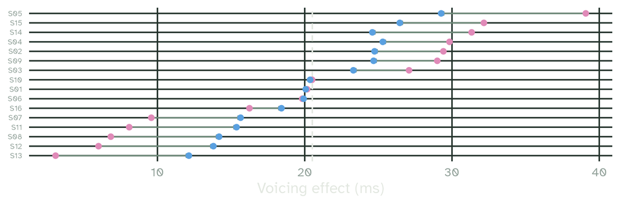

Pink: each speaker’s raw voicing effect. Blue: the model’s estimate, shrunk towards the average. When interpreting individual speakers, remember that their estimates borrow strength from everyone else.

# Your turn

## Real data: `lexdec`

The `lexdec` data from `{languageR}` (Baayen, 2008): 21 participants made lexical decisions on 79 English words. `RT` is the log reaction time; 12 participants are native speakers of English, 9 are not.

```r
library(languageR)
lexdec |> select(Subject, Word, RT, Frequency, NativeLanguage) |> head(3)
```

```
  Subject   Word       RT Frequency NativeLanguage
1      A1    owl 6.340359  4.859812        English
2      A1   mole 6.308098  4.605170        English
3      A1 cherry 6.349139  4.997212        English
```

## Exercises

1. Which random slopes does the design allow for `Frequency` (a property of words) and `NativeLanguage` (a property of participants)?
2. Fit `RT ~ Frequency + NativeLanguage` with the maximal random effects structure justified by the design. What happens?
3. Refit with the `bobyqa` optimiser. Did the fixed effects change?
4. Test `NativeLanguage` with a likelihood ratio test.

## Solutions

1. Frequency varies within participants, not within words: `(1 + Frequency | Subject)`. NativeLanguage varies within words, not within participants: `(1 + NativeLanguage | Word)`

```r
lex_max <- lmer(RT ~ Frequency + NativeLanguage +
                  (1 + Frequency | Subject) + (1 + NativeLanguage | Word),
                data = lexdec)
```

```
Warning in checkConv(attr(opt, "derivs"), opt$par, ctrl = control$checkConv, : Model failed to converge with max|grad| = 0.00767209 (tol = 0.002, component 1)
  See ?lme4::convergence and ?lme4::troubleshooting.
```

## Solutions

```r
lex_bob <- update(lex_max, control = lmerControl(optimizer = "bobyqa"))
cbind(default = fixef(lex_max), bobyqa = fixef(lex_bob))
```

```
                        default      bobyqa
(Intercept)          6.54085899  6.54087587
Frequency           -0.03987850 -0.03987869
NativeLanguageOther  0.07862839  0.07859110
```

The warning disappears, and the estimates barely change.

```r
lex_full <- update(lex_bob, REML = FALSE)
lex_null <- update(lex_full, . ~ . - NativeLanguage)
anova(lex_null, lex_full)
```

```
Data: lexdec
Models:
lex_null: RT ~ Frequency + (1 + Frequency | Subject) + (1 + NativeLanguage | Word)
lex_full: RT ~ Frequency + NativeLanguage + (1 + Frequency | Subject) + (1 + NativeLanguage | Word)
         npar     AIC     BIC logLik -2*log(L)  Chisq Df Pr(>Chisq)
lex_null    9 -929.64 -880.92 473.82   -947.64
lex_full   10 -930.10 -875.96 475.05   -950.10 2.4608  1     0.1167
```

With random intercepts only, the same test gives p = 0.012. The by-word slope for NativeLanguage makes the test more cautious.

## Summary

- Simulate first: you can only check a model against a known truth
- `summary()`, `fixef()`, `ranef()`, `coef()`, `VarCorr()`, `confint()`, `predict(re.form = NA)`
- `lme4` gives no p-values: use likelihood ratio tests (with ML), or `{lmerTest}`
- Random slopes only where the predictor varies within the group
- Convergence warnings and singular fits: check, change optimiser, then simplify
- Marginal vs conditional `R²`

## Slides and code

[figure not shown]

These slides

mcanzi.de/ws26_statistics/11_mixed_models_2.html

Code, data and all lectures

github.com/mcanzi/ws26_statistics